# Cluster_composition_tests

Sarah Hazell Pickering

2025-02-03

- Step 1: Cluster composition plot
  - save cluster counts and proportions by condition & time (no replicate information) “cluster_composition_condition_time.tsv”
- Step 2: Test if the proportion of white and beige cells in each cluster is different; aka is it different from a 0.5 white/beige proportion. To simplify this I’m only going to check cells from the majority time point for each cluster.
  - save test result “cluster_composition_test.tsv”

```r
library(BPCells)
library(Seurat)
library(dplyr)
library(ggplot2)
library(here)
library(patchwork)
library(tidyr)
```

```r
module = "beige_vs_white"
dataname = "downsample"
load_data = T #loading data
subset_data = F

rmd_filename = "beige_vs_white_downsample_cluster_tests"
i_am(file.path("analysis", module, paste0(rmd_filename,".Rmd")))
```

```
## here() starts at /projects/imb-pkbphil/sp/sc_rnaseq/progenitor_scrnaseq
```

```r
odir = here("output", module, dataname)
```

```r
set.seed(8)
fig_dir = here("analysis", module, "figures", rmd_filename)
if (!dir.exists(fig_dir)) dir.create(fig_dir, recursive = TRUE)
knitr::opts_chunk$set(fig.path = paste0(fig_dir, "/"),
                      dev = c("png","pdf"))

if (!dir.exists(odir)) dir.create(odir, recursive = TRUE)
```

```r
theme_hp = theme_classic(base_size = 15) +
  theme(axis.line = element_line(linewidth = 0.25),
        axis.ticks = element_line(linewidth = 0.25),
        strip.background = element_blank())
theme_set(theme_hp)
pal = c("#1F78B4","#85C2EA","#B3B3B3", "#F18486", "#E31A1C")
clusters = MetBrewer::met.brewer("Redon", 12)
spectral = rev(RColorBrewer::brewer.pal(n = 11, name = 'Spectral'))
```

## Read data

```r
if (subset_data){
  sbs = readRDS(here(odir, "10%_complete_analysis.rds"))
} else {
  sbs = readRDS(here(odir, "complete_analysis.rds"))
  DefaultAssay(sbs) = "RNA"
}
Idents(sbs) = "seurat_clusters"
Idents(sbs) = factor(Idents(sbs), levels=0:(length(unique(Idents(sbs))))-1)
sbs
```

```
## An object of class Seurat
## 36601 features across 44693 samples within 1 assay
## Active assay: RNA (36601 features, 2000 variable features)
##  3 layers present: scale.data, data, counts
##  3 dimensional reductions calculated: pca, umap, tsne
```

```r
table(Idents(sbs))
```

```
##
##     0     1     2     3     4     5     6     7     8     9    10    11
## 12867  8068  7241  6812  3478  3196  1266   701   363   325   284    92
```

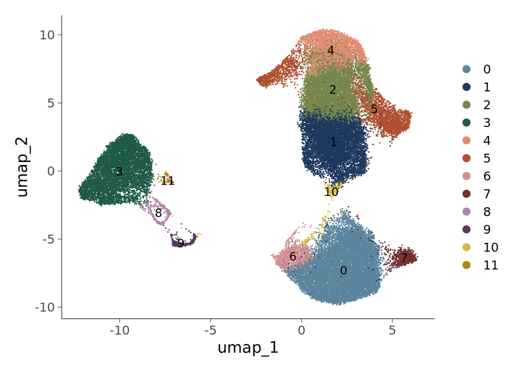

```r
DimPlot(sbs, cols= clusters, label = T) + theme_hp
```

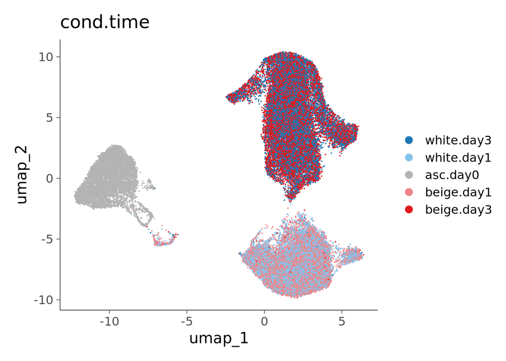

```r
DimPlot(sbs, group.by="cond.time",cols=pal, shuffle=T) + theme_hp
```

## Composition plots (per condition + time)

(not per sample)

```r
tcomp = group_by(sbs@meta.data, cond.time,seurat_clusters, time, condition) %>% dplyr::count(name="n_cells")
tcomp= tcomp[order(tcomp$n_cells, decreasing = T),]
#calculate proportions directly, then plot percentage just for the three cyc;ling cells
tcomp= group_by(tcomp, cond.time) %>% mutate(cells_per_sample = n_cells/sum(n_cells))
tcomp= group_by(tcomp, seurat_clusters) %>% mutate(prop.cells_per_cluster = n_cells/sum(n_cells), n.cells_per_cluster = sum(n_cells))
head(tcomp)
```

```
## # A tibble: 6 × 8
## # Groups:   seurat_clusters [4]
##   cond.time  seurat_clusters time  condition n_cells cells_per_sample
##   <fct>      <fct>           <chr> <chr>       <int>            <dbl>
## 1 asc.day0   3               day0  asc          6810            0.937
## 2 beige.day1 0               day1  beige        6456            0.845
## 3 white.day1 0               day1  white        6337            0.830
## 4 beige.day3 1               day3  beige        4013            0.362
## 5 white.day3 1               day3  white        3971            0.358
## 6 white.day3 2               day3  white        3758            0.339
## # ℹ 2 more variables: prop.cells_per_cluster <dbl>, n.cells_per_cluster <int>
```

```r
str(tcomp)
```

```
## gropd_df [39 × 8] (S3: grouped_df/tbl_df/tbl/data.frame)
##  $ cond.time             : Factor w/ 5 levels "white.day3","white.day1",..: 3 4 2 5 1 1 5 5 1 5 ...
##  $ seurat_clusters       : Factor w/ 12 levels "0","1","2","3",..: 4 1 1 2 2 3 3 5 5 6 ...
##  $ time                  : chr [1:39] "day0" "day1" "day1" "day3" ...
##  $ condition             : chr [1:39] "asc" "beige" "white" "beige" ...
##  $ n_cells               : int [1:39] 6810 6456 6337 4013 3971 3758 3470 1752 1726 1698 ...
##  $ cells_per_sample      : num [1:39] 0.937 0.845 0.83 0.362 0.358 ...
##  $ prop.cells_per_cluster: num [1:39] 1 0.502 0.493 0.497 0.492 ...
##  $ n.cells_per_cluster   : int [1:39] 6812 12867 12867 8068 8068 7241 7241 3478 3478 3196 ...
##  - attr(*, "groups")= tibble [12 × 2] (S3: tbl_df/tbl/data.frame)
##   ..$ seurat_clusters: Factor w/ 12 levels "0","1","2","3",..: 1 2 3 4 5 6 7 8 9 10 ...
##   ..$ .rows          : list<int> [1:12]
##   .. ..$ : int [1:4] 2 3 25 26
##   .. ..$ : int [1:4] 4 5 23 27
##   .. ..$ : int [1:4] 6 7 29 32
##   .. ..$ : int [1:3] 1 38 39
##   .. ..$ : int [1:2] 8 9
##   .. ..$ : int [1:4] 10 11 28 36
##   .. ..$ : int [1:4] 12 13 30 33
##   .. ..$ : int [1:4] 14 16 34 35
##   .. ..$ : int 15
##   .. ..$ : int [1:4] 17 18 31 37
##   .. ..$ : int [1:4] 19 21 22 24
##   .. ..$ : int 20
##   .. ..@ ptype: int(0)
##   ..- attr(*, ".drop")= logi TRUE
```

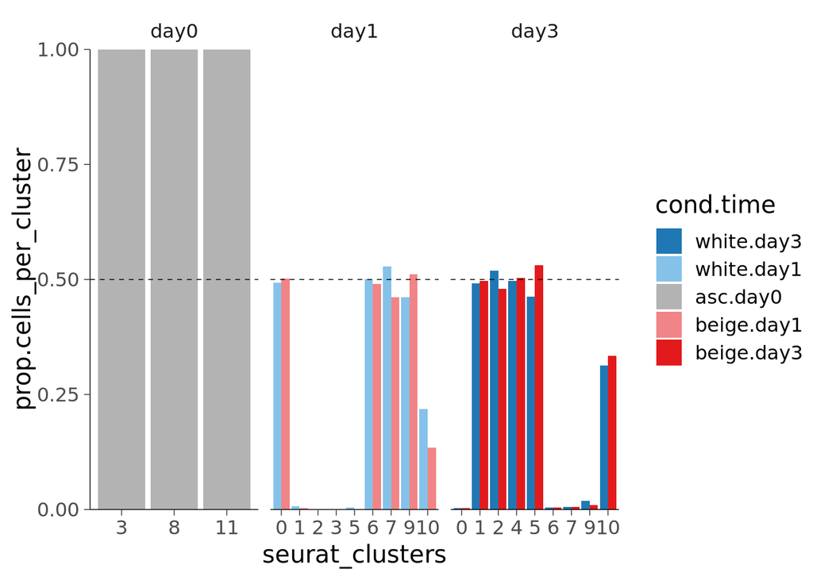

```r
ggplot(tcomp, aes(x=seurat_clusters, fill=cond.time, y=prop.cells_per_cluster)) +
  geom_bar(position="dodge", stat='identity') +
  scale_fill_manual(values=pal) + facet_grid(~time, scales="free_x") +
  geom_hline(yintercept = 0.5, linetype="dashed", linewidth=0.25) +
  scale_y_continuous(expand=c(0,0))
```

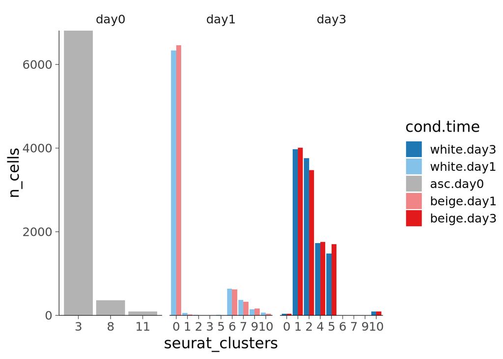

```r
ggplot(tcomp, aes(x=seurat_clusters, fill=cond.time, y=n_cells)) +
  geom_bar(position="dodge", stat='identity') +
  scale_fill_manual(values=pal) + facet_grid(~time, scales="free_x")+
  scale_y_continuous(expand=c(0,0))
```

```r
write.table(tcomp, here(odir, "cluster_composition_condition_time.tsv"),
            sep="\t", quote = F, row.names = F)
```

## Best matches

For plotting and testing we want to focus of the main timepoint for each cluster; this selects the majority timepoint per cluster and then subsets our frequency table.

```r
time_per_cluster = group_by(tcomp, seurat_clusters, time) %>% summarise(n_cells = sum(n_cells)) %>%
  slice_max(n=1, order_by = n_cells)  %>% mutate(cluster=paste0("b",seurat_clusters)) %>%
    select(seurat_clusters, cluster, time)
time_per_cluster
```

```
## # A tibble: 12 × 3
## # Groups:   seurat_clusters [12]
##    seurat_clusters cluster time
##    <fct>           <chr>   <chr>
##  1 0               b0      day1
##  2 1               b1      day3
##  3 2               b2      day3
##  4 3               b3      day0
##  5 4               b4      day3
##  6 5               b5      day3
##  7 6               b6      day1
##  8 7               b7      day1
##  9 8               b8      day0
## 10 9               b9      day1
## 11 10              b10     day3
## 12 11              b11     day0
```

```r
bestmatches = merge(tcomp, time_per_cluster, by=c("seurat_clusters","time"), all=F)
bestmatches$condition = gsub("\\..*","",bestmatches$cond.time)
bestmatches
```

```
##    seurat_clusters time  cond.time condition n_cells cells_per_sample
## 1                0 day1 beige.day1     beige    6456      0.845358125
## 2                0 day1 white.day1     white    6337      0.829776090
## 3                1 day3 beige.day3     beige    4013      0.362282206
## 4                1 day3 white.day3     white    3971      0.358490566
## 5               10 day3 beige.day3     beige      95      0.008576329
## 6               10 day3 white.day3     white      89      0.008034666
## 7               11 day0   asc.day0       asc      92      0.012663455
## 8                2 day3 white.day3     white    3758      0.339261533
## 9                2 day3 beige.day3     beige    3470      0.313261713
## 10               3 day0   asc.day0       asc    6810      0.937370957
## 11               4 day3 beige.day3     beige    1752      0.158165568
## 12               4 day3 white.day3     white    1726      0.155818362
## 13               5 day3 beige.day3     beige    1698      0.153290602
## 14               5 day3 white.day3     white    1480      0.133610183
```

[output cut: 29 more lines]

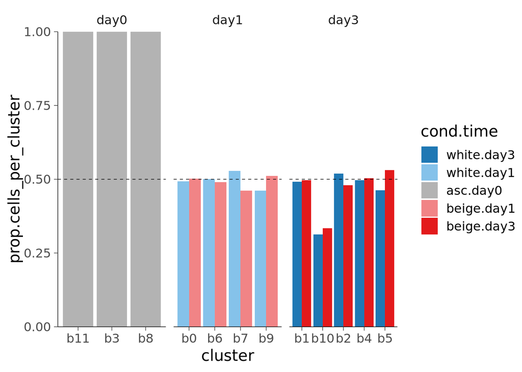

```r
ggplot(bestmatches, aes(x=cluster, fill=cond.time, y=prop.cells_per_cluster)) +
  geom_bar(position="dodge", stat='identity') +
  scale_fill_manual(values=pal) + facet_wrap(~time, scales="free_x") +
  geom_hline(yintercept = 0.5, linetype="dashed", linewidth=0.25)+ facet_grid(~time, scales="free_x")+
  scale_y_continuous(expand=c(0,0))
```

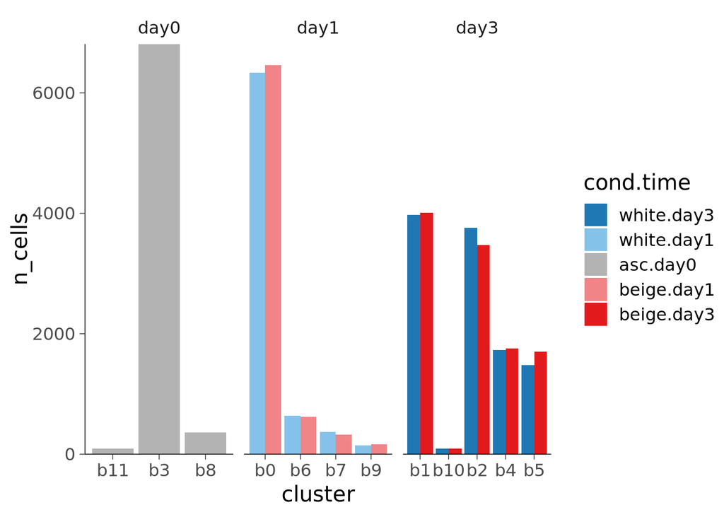

```r
ggplot(bestmatches, aes(x=cluster, fill=cond.time, y=n_cells)) +
  geom_bar(position="dodge", stat='identity') +
  scale_fill_manual(values=pal) + facet_wrap(~time, scales="free_x")+ facet_grid(~time, scales="free_x")+
  scale_y_continuous(expand=c(0,0.05))
```

^ the proportions plotted above also include cells from a different time point that get included in the count. E.g. cluster 2 here has some day1 cells in it which is why day3 white and beige don’t add up to 100%. So to be totally covering our bases we should include them in the proportion test - then we have to do individual tests to figure out where the change is coming from.

## White vs beige proportion test

Test if the proportion of white and beige cells in each cluster is different; aka is it different from a 0.5 white/beige proportion. To simplify this I’m only going to check cells from the majority time point for each cluster.

```r
clusters_to_test = filter(bestmatches, condition == "beige") %>% pull(cluster)
clusters_to_test
```

```
## [1] "b0"  "b1"  "b10" "b2"  "b4"  "b5"  "b6"  "b7"  "b9"
```

```r
wvb_df = filter(bestmatches, cluster %in% clusters_to_test) %>%
  pivot_wider(names_from=condition, values_from = n_cells, id_cols = cluster) %>%
  as.data.frame()
rownames(wvb_df) = wvb_df$cluster
wvb = data.matrix(wvb_df)
wvb = wvb[,2:3]
wvb
```

```
##     beige white
## b0   6456  6337
## b1   4013  3971
## b10    95    89
## b2   3470  3758
## b4   1752  1726
## b5   1698  1480
## b6    621   634
## b7    323   370
## b9    166   150
```

```r
## quick test are any different than 50%?
prop.test(wvb) #Yes some are different
```

```
##
##  9-sample test for equality of proportions without continuity correction
##
## data:  wvb
## X-squared = 32.112, df = 8, p-value = 8.895e-05
## alternative hypothesis: two.sided
## sample estimates:
##    prop 1    prop 2    prop 3    prop 4    prop 5    prop 6    prop 7    prop 8
## 0.5046510 0.5026303 0.5163043 0.4800775 0.5037378 0.5342983 0.4948207 0.4660895
##    prop 9
## 0.5253165
```

```r
clu_tests  = list()
tests = data.frame(cluster = clusters_to_test, prop = wvb[,"beige"]/(wvb[,"white"]+wvb[,"beige"]),p.value=NA, conf.int.1=NA, conf.int.2=NA)

for (clu in tests$cluster){
  res = prop.test(matrix(wvb[clu,], ncol = 2), conf.level=0.99)
  clu_tests[[clu]] = res
  tests[tests$cluster == clu,]$p.value = res$p.value
  tests[tests$cluster == clu,]$conf.int.1 = res$conf.int[[1]]
  tests[tests$cluster == clu,]$conf.int.2 = res$conf.int[[2]]
}
clu_tests[[1]]$p.value
```

```
## [1] 0.2968243
```

```r
clu_tests[[1]]
```

```
##
##  1-sample proportions test with continuity correction
##
## data:  matrix(wvb[clu, ], ncol = 2), null probability 0.5
## X-squared = 1.0884, df = 1, p-value = 0.2968
## alternative hypothesis: true p is not equal to 0.5
## 99 percent confidence interval:
##  0.4932262 0.5160710
## sample estimates:
##        p
## 0.504651
```

```r
tests$p.adjust = p.adjust(tests$p.value, method="fdr")
tests = merge(tests, time_per_cluster, by=c("cluster"))
tests
```

```
##   cluster      prop      p.value conf.int.1 conf.int.2    p.adjust
## 1      b0 0.5046510 0.2968242754  0.4932262  0.5160710 0.667854620
## 2      b1 0.5026303 0.6463397189  0.4881579  0.5170982 0.734809777
## 3     b10 0.5163043 0.7124222499  0.4198679  0.6115740 0.734809777
## 4      b2 0.4800775 0.0007360948  0.4648969  0.4952948 0.003312426
## 5      b4 0.5037378 0.6716303417  0.4817701  0.5256912 0.734809777
## 6      b5 0.5342983 0.0001184515  0.5113008  0.5571519 0.001066063
## 7      b6 0.4948207 0.7348097768  0.4581945  0.5315020 0.734809777
## 8      b7 0.4660895 0.0805687565  0.4171209  0.5157106 0.241706270
## 9      b9 0.5253165 0.3987722748  0.4516232  0.5979459 0.717790095
##   seurat_clusters time
## 1               0 day1
## 2               1 day3
## 3              10 day3
## 4               2 day3
## 5               4 day3
## 6               5 day3
## 7               6 day1
## 8               7 day1
## 9               9 day1
```

## Plot X-squared CIs

```r
to_plot = dplyr::rename(tests, prop_beige=prop, conf.int.1_beige=conf.int.1, conf.int.2_beige=conf.int.2)
to_plot$prop_white = 1-to_plot$prop_beige
to_plot$conf.int.1_white = to_plot$conf.int.1_beige + (to_plot$prop_white - to_plot$prop_beige)
to_plot$conf.int.2_white = to_plot$conf.int.2_beige + (to_plot$prop_white - to_plot$prop_beige)
to_plot = pivot_longer(to_plot, matches("white|beige"),
                       names_to = c(".value","condition"),
                       names_pattern = "(.*)_(.*)",
                     )
to_plot$cond.time = paste(to_plot$condition, sep=".", to_plot$time)
head(to_plot)
```

```
## # A tibble: 6 × 10
##   cluster p.value p.adjust seurat_clusters time  condition  prop conf.int.1
##   <chr>     <dbl>    <dbl> <fct>           <chr> <chr>     <dbl>      <dbl>
## 1 b0        0.297    0.668 0               day1  beige     0.505      0.493
## 2 b0        0.297    0.668 0               day1  white     0.495      0.484
## 3 b1        0.646    0.735 1               day3  beige     0.503      0.488
## 4 b1        0.646    0.735 1               day3  white     0.497      0.483
## 5 b10       0.712    0.735 10              day3  beige     0.516      0.420
## 6 b10       0.712    0.735 10              day3  white     0.484      0.387
## # ℹ 2 more variables: conf.int.2 <dbl>, cond.time <chr>
```

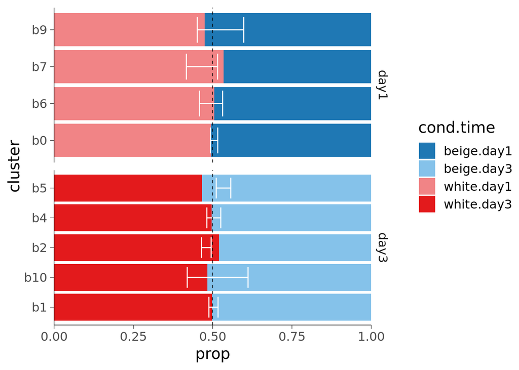

```r
ggplot(to_plot, aes(y=cluster, fill=cond.time, x=prop)) +
  geom_bar(stat='identity')     +
  geom_errorbar(data=filter(to_plot, condition =="beige"), aes(xmin=conf.int.1, xmax=conf.int.2),
                 width=0.7, linewidth=0.5, colour="white") +
  geom_vline(xintercept = 0.5, linetype="dashed",linewidth=0.25) +
  scale_fill_manual(values=pal[c(1,2,4,5)]) + facet_grid(time~., scales="free_y") +
  scale_x_continuous(expand=c(0,0))
```

## Column version

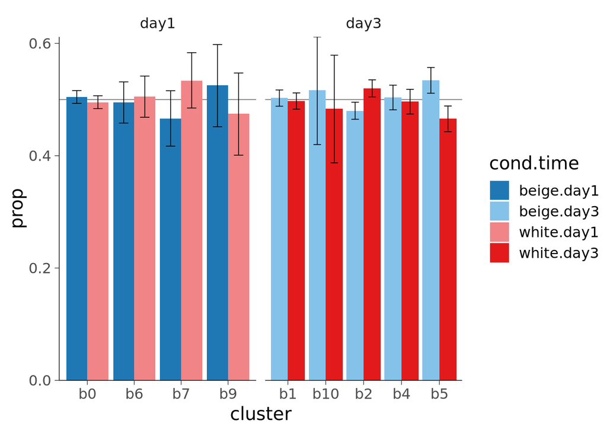

```r
ggplot(to_plot, aes(x=cluster, fill=cond.time, y=prop))  +
  geom_hline(yintercept = 0.5, linewidth=0.4, colour="grey55") +
  geom_bar(position="dodge", stat='identity') +
  geom_errorbar( aes(ymin=conf.int.1, ymax=conf.int.2),
                 position=position_dodge(0.9), width=0.4, linewidth=0.3) +
  scale_fill_manual(values=pal[c(1,2,4,5)]) + facet_wrap(~time, scales="free_x")  +
  scale_y_continuous(expand=c(0,0))
```

```r
write.table(tests, here(odir, "cluster_composition_test.tsv"),
            sep="\t", quote=F, row.names=F)
```